# Introduction

- Long-Term Opioid Therapy (LTOT) can post a series of severe physical and mental issues for patients. Long Term Opioid Therapy is defined as the continuous use of opioid medication with 90% of days covered over six months.

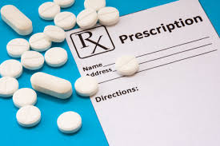

- To assist Humana in identifying patients likely to overuse opioids and make a timely intervention, first, we used the given dataset to identify and label patients having LTOT. Then we compared LTOT and non-LTOT patients to discover the most different features (e.g. opioid use history, the sum of claim charged amount). After that, we performed feature engineering to get essential features for each patient. Next, using our preprocessed dataset, we used cross-validation to tune, evaluate, and choose the best model among Logistic Regression, Random Forest, and Light Gradient Boosting models. Lastly, we trained our chosen LightGB model on the whole train dataset and make predictions on the holdout dataset.

## About the dataset

- The training dataset covers 4-year medical records of 14,000 patients and has six million rows, each of which provides details corresponding to an event for the particular member. The holdout dataset covers 6,000 patients and only includes data up to the first opioid naïve event. In this dataset the four main event categories are: Claim, Diagnosis, Call, and RxClaim.

## Load the data

```python
# import useful packages
import numpy as np
import pandas as pd
import matplotlib.pyplot as plt
import seaborn as sns
%matplotlib inline
```

```python
# read the raw data
Data = pd.read_csv("HMAHCC_COMP.csv")
testData = pd.read_csv("holdOut_processed.csv")
```

```python
# serve as mark in order to distinguish training and testing data
testID = pd.DataFrame({'id':testData.id.unique()})
trainID = pd.DataFrame({'id':Data.id.unique()})
```

```python
print(trainID.shape)
print(testID.shape)
```

```
(14000, 1)
(6000, 1)
```

```python
# We only need to care about patient behavior before opoid naive because we are here to make predictions
trainData = Data[Data.Days <= 0]
```

```python
fullData = pd.concat([trainData, testData], axis=0)
```

```python
print(fullData.shape)
```

```
(4320622, 20)
```

## Labeling LTOT

- To correctly identify and label the event of interest, we subsetted the opioid paid RX claim data. Firstly, we sorted the data by patient id, drug types, and days to avoid overlapping. Then, we identify opioid naïve events of each patient. After that, based on days supplied, we calculated how many days each patient use opioid drugs within 180 days after the last opioid naïve event. This number is reset whenever a patient has a new opioid naive event. Within 180 days after each opioid naive event, if a patient has more than 162 days of opioid supplies, she or he will be labeled as LTOT.
- To predict the probability of having LTOT for a patient, we focused on analyzing opioid usage history and each of the main event categories to learn from their past behaviors.

```python
label = pd.read_csv("label.csv")
```

```python
label.shape
```

```
(13949, 2)
```

```python
# Merge train data with label
trainDataLabel = trainData.merge(label, on='id')
```

# Exploratory Data Analysis

[figure not shown]

- This functions is created to show the difference between LTOT and non-LTOT of a particular attribute by calculating the total amount

```python
def analyze_attr(attr, df):
    df1 = df[['id', attr, 'LTOP']].copy().groupby(['id', attr]).mean().reset_index()
    df2 = df1.groupby([attr, 'LTOP']).count().reset_index()
    df2.columns = [attr, 'LTOP', 'count']

    df3 = df2.pivot_table(values='count', index=[attr], columns=['LTOP']).reset_index()
    df3.columns = [attr, 'LTOP_0', 'LTOP_1']
    df3['diff'] = df3.LTOP_1 - df3.LTOP_0
    return df3.sort_values('diff', ascending=False)
```

- This function is created to visualize the formal analysis in a countplot

```python
def plot_attr(attr, df, size):
    df1 = df[['id', attr, 'LTOP']].copy().groupby(['id', attr]).mean().reset_index()
    plt.figure(figsize=(size, 4))
    sns.countplot(x=attr, hue='LTOP', palette='coolwarm', data=df1)
```

### 1. Opioid RX Claim

- When labeling LTOT, we realized that the history of opioid usage might be highly correlated with the likelihood of future LTOT. So we decided to discover opioid usage history first. We tried to explore whether LTOT and non-LTOT patients would have different patterns in various attributes provided in the data.

```python
EDA_data = Data.merge(label, on='id')
```

```python
opioid = EDA_data[(pd.notnull(EDA_data['PAY_DAY_SUPPLY_CNT']))&(EDA_data['event_descr']=='RX Claim - Paid')]
#analyze_attr('event_attr5',trainDataLabel).head(5)
```

```python
analyze_attr('event_attr1',opioid).head(5)
```

|  | event_attr1 | LTOP_0 | LTOP_1 | diff |
| --- | --- | --- | --- | --- |
| 1 | OPIOID AGONISTS | 4184.0 | 4876.0 | 692.0 |
| 2 | OPIOID ANTAGONISTS | 72.0 | 302.0 | 230.0 |
| 4 | OPIOID PARTIAL AGONISTS | 69.0 | 157.0 | 88.0 |
| 3 | OPIOID COMBINATIONS | 6574.0 | 5127.0 | -1447.0 |
| 0 | ANTIPERISTALTIC AGENTS | NaN | 1.0 | NaN |

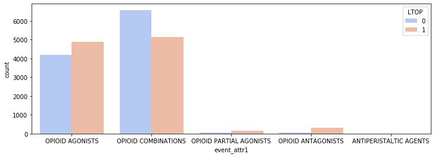

```python
plot_attr('event_attr1',opioid,12)
```

- From the count plot above, we found out that patients who had LTOT would use certain drug classes more than non-LTOT patients, indicating the drug class description may have predictive power in distinguishing the LTOT risk. For example, Opioid Agonist is more likely to cause LTOT.
- With a similar approach, we can also find other potential descriptive attributes to distinguish between LTOT and non-LTOT patients which are GPI Drug Class Description and Speciality.

```python
analyze_attr('event_attr5',opioid)
analyze_attr('Specialty',opioid)
plot_attr('event_attr5',opioid,50)
plot_attr('Specialty',opioid,50)
```

[output not shown]

- Moreover, the number of opioid prescriptions and the number of opioid drug supplies are also different between LTOT and non-LTOT patients. Meanwhile, we found a significant difference between LTOT and non-LTOT patients of how many drugs they received at the opioid naive day,

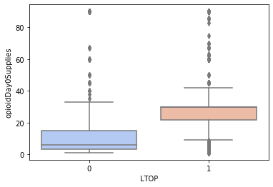

```python
opioidDay0Supplies = opioid[opioid.Days==0][['id','PAY_DAY_SUPPLY_CNT','LTOP']].groupby('id').max().reset_index() #7
opioidDay0Supplies.columns = ['id','opioidDay0Supplies','LTOP']
opioidDay0Supplies.head()
sns.boxplot(x='LTOP',y='opioidDay0Supplies',data=opioidDay0Supplies,palette='coolwarm')
```

## 2. Other RX Claims

- Besides RX Claims related to opioids, there might exist other attributes that we can add to our predictors. By plotting the average count of Rx Claim of LTOT and non-LTOT patients, we found some drug classes and drug groups that are used differently among LTOT and non-LTOT patients. Patients having LTOT uses a lot more pulmonary fibrosis agents, pulmonary hypertension, immunomodulators than non-LTOT patients.

```python
OtherRX = EDA_data[(EDA_data['event_descr']=='RX Claim - Paid')& (EDA_data['Days']<=0)]
OtherRX.head()
```

|  | id | event_descr | event_attr1 | event_attr2 | event_attr3 | event_attr4 | event_attr5 | event_attr6 | event_attr7 | event_attr8 | ... | event_attr10 | Days | PAY_DAY_SUPPLY_CNT | PAYABLE_QTY | MME | DRUG_TYPE | Specialty | Specialty2 | Specialty3 | LTOP |
| --- | --- | --- | --- | --- | --- | --- | --- | --- | --- | --- | --- | --- | --- | --- | --- | --- | --- | --- | --- | --- | --- |
| 0 | ID10010854159 | RX Claim - Paid | BIGUANIDES | NaN | 5 | 2.35 | METFORMIN HCL | DIABETES | NaN | METFORMIN HCL TAB 500 MG | ... | 27250050.0 | -664 | NaN | NaN | NaN | NaN | NaN | NaN | NaN | 0 |
| 1 | ID10010854159 | RX Claim - Paid | BETA BLOCKERS CARDIO-SELECTIVE | NaN | 5 | 2.35 | ATENOLOL | CARDIO | NaN | ATENOLOL TAB 25 MG | ... | 33200020.0 | -659 | NaN | NaN | NaN | NaN | NaN | NaN | NaN | 0 |
| 3 | ID10010854159 | RX Claim - Paid | FLUOROQUINOLONES | NaN | 5.8 | 3.15 | CIPROFLOXACIN HCL | INF-ANTIBIOTICS | NaN | CIPROFLOXACIN HCL TAB 500 MG (BASE EQUIV) | ... | 5000020.0 | -646 | NaN | NaN | NaN | NaN | NaN | NaN | NaN | 0 |
| 4 | ID10010854159 | RX Claim - Paid | HMG COA REDUCTASE INHIBITORS | NaN | 13 | 10.35 | PRAVASTATIN SODIUM | CARDIO | NaN | PRAVASTATIN SODIUM TAB 20 MG | ... | 39400065.0 | -646 | NaN | NaN | NaN | NaN | NaN | NaN | NaN | 0 |
| 5 | ID10010854159 | RX Claim - Paid | THIAZIDES AND THIAZIDE-LIKE DIURETICS | NaN | 5 | 2.35 | HYDROCHLOROTHIAZIDE | CARDIO | NaN | HYDROCHLOROTHIAZIDE TAB 25 MG | ... | 37600040.0 | -644 | NaN | NaN | NaN | NaN | NaN | NaN | NaN | 0 |

5 rows × 21 columns

- This functions is created to show the difference between LTOT and non-LTOT of a particular attribute by calculating the average value of each patient

```python
def getcountdiff(attr,df,name):
    df1 = df[['id',attr, 'LTOP','event_attr5']].copy().groupby(['id',attr,'LTOP']).count().reset_index()
    df2 =  df1.copy().groupby([attr,'LTOP']).mean().reset_index()
    df2.columns=[attr,'LTOP','count']
    df2.sort_values('count',ascending=False,inplace=True)
    df3 = df2.pivot(index=attr, columns='LTOP', values='count').reset_index()
    df3.columns=[name,'LTOP_0','LTOP_1']
    df3['diff']=abs(df3['LTOP_0']-df3['LTOP_1'])
    df3.sort_values('diff',ascending=False,inplace=True)
    return df3.head(5)
```

- This function is created to visualize the formal analysis in a countplot

```python
def plotcountdiff(attr,df,name):
    df1 = df[['id',attr, 'LTOP','event_attr5']].copy().groupby(['id',attr,'LTOP']).count().reset_index()
    df2 =  df1.copy().groupby([attr,'LTOP']).mean().reset_index()
    df2.columns=[attr,'LTOP','count']
    df2.sort_values('count',ascending=False,inplace=True)
    df3 = df2.pivot(index=attr, columns='LTOP', values='count').reset_index()
    df3.columns=[name,'LTOP_0','LTOP_1']
    df3['diff']=abs(df3['LTOP_0']-df3['LTOP_1'])
    df3.sort_values('diff',ascending=False,inplace=True)
    df4 = df3.head(5).melt(id_vars=name,value_vars=['LTOP_0','LTOP_1'])
    return sns.barplot(y=name, x='value', hue='variable', data=df4,palette='coolwarm')
```

```python
getcountdiff('event_attr1',OtherRX,'drugclass')
```

|  | drugclass | LTOP_0 | LTOP_1 | diff |
| --- | --- | --- | --- | --- |
| 197 | GROWTH HORMONES | 52.000000 | 8.000000 | 44.000000 |
| 344 | RESTLESS LEG SYNDROME (RLS) AGENTS | 30.000000 | 6.000000 | 24.000000 |
| 333 | PULMONARY FIBROSIS AGENTS | 3.333333 | 19.500000 | 16.166667 |
| 335 | PULMONARY HYPERTENSION - PHOSPHODIESTERASE INH... | 5.125000 | 17.333333 | 12.208333 |
| 215 | IMMUNOMODULATORS | 5.166667 | 16.000000 | 10.833333 |

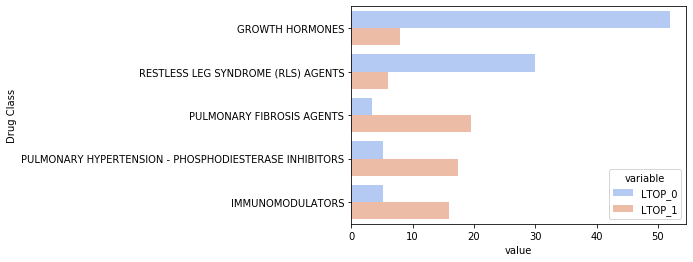

```python
plotcountdiff('event_attr1',OtherRX,'Drug Class')
```

```python
getcountdiff('event_attr6',OtherRX,'Drug Group')
```

[output not shown]

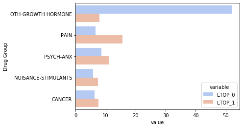

```python
plotcountdiff('event_attr6',OtherRX,'Drug Group')
```

## 3. Fully Paid Claim

- For fully paid claim events, we tried to identify what diagnoses and treatment place are the most different between LTOT and non-LTOT patients.

```python
FullyPaid = EDA_data[(EDA_data['event_descr']=='Fully Paid Claim')& (EDA_data['Days']<=0)]
FullyPaid.head()
```

|  | id | event_descr | event_attr1 | event_attr2 | event_attr3 | event_attr4 | event_attr5 | event_attr6 | event_attr7 | event_attr8 | ... | event_attr10 | Days | PAY_DAY_SUPPLY_CNT | PAYABLE_QTY | MME | DRUG_TYPE | Specialty | Specialty2 | Specialty3 | LTOP |
| --- | --- | --- | --- | --- | --- | --- | --- | --- | --- | --- | --- | --- | --- | --- | --- | --- | --- | --- | --- | --- | --- |
| 7 | ID10010854159 | Fully Paid Claim | ALLERGIC RHINITIS, CAUSE UNSPECIFIED | OFFICE | 100.0 | 0.0 | 67.99 | NaN | NaN | NaN | ... | NaN | -630 | NaN | NaN | NaN | NaN | NaN | NaN | NaN | 0 |
| 17 | ID10010854159 | Fully Paid Claim | UNSPECIFIED ESSENTIAL HYPERTENSION | ON CAMPUS-HOSPITAL OUTPATIENT | 312.0 | 28.11 | 13.58 | NaN | NaN | NaN | ... | NaN | -595 | NaN | NaN | NaN | NaN | NaN | NaN | NaN | 0 |
| 18 | ID10010854159 | Fully Paid Claim | UNSPECIFIED ESSENTIAL HYPERTENSION | OFFICE | 100.0 | 0.0 | 67.99 | NaN | NaN | NaN | ... | NaN | -588 | NaN | NaN | NaN | NaN | NaN | NaN | NaN | 0 |
| 23 | ID10010854159 | Fully Paid Claim | URINARY TRACT INFECTION, SITE NOT SPECIFIED | OFFICE | 100.0 | 0.0 | 67.99 | NaN | NaN | NaN | ... | NaN | -568 | NaN | NaN | NaN | NaN | NaN | NaN | NaN | 0 |
| 34 | ID10010854159 | Fully Paid Claim | ACUTE FRONTAL SINUSITIS | OFFICE | 450.0 | 143.61 | 5.23 | NaN | NaN | NaN | ... | NaN | -498 | NaN | NaN | NaN | NaN | NaN | NaN | NaN | 0 |

5 rows × 21 columns

```python
getcountdiff('event_attr1',FullyPaid,'diagnosis')
```

|  | diagnosis | LTOP_0 | LTOP_1 | diff |
| --- | --- | --- | --- | --- |
| 7769 | OTHER COMPLICATIONS OF SKIN GRAFT (ALLOGRAFT) ... | 79.0 | 16.0 | 63.0 |
| 6096 | MALIGNANT NEOPLASM OF MIDDLE THIRD OF ESOPHAGUS | 5.0 | 61.0 | 56.0 |
| 6066 | MALIGNANT NEOPLASM OF LEFT OVARY | 2.0 | 56.0 | 54.0 |
| 7702 | OTHER CHRONIC HEMATOGENOUS OSTEOMYELITIS, RIGH... | 1.0 | 44.0 | 43.0 |
| 13439 | VESICOINTESTINAL FISTULA | 5.0 | 44.0 | 39.0 |

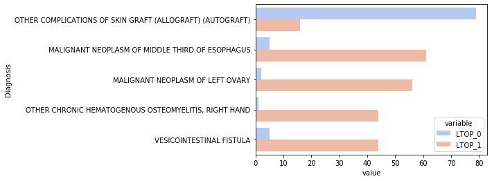

```python
plotcountdiff('event_attr1',FullyPaid,'Diagnosis')
```

```python
getcountdiff('event_attr2',FullyPaid,'Treatment Place')
```

|  | Treatment Place | LTOP_0 | LTOP_1 | diff |
| --- | --- | --- | --- | --- |
| 7 | COMPREHENSIVE OUTPATIENT REHAB FACILITY | 22.000000 | 7.000000 | 15.000000 |
| 16 | INPATIENT HOSPITAL | 13.014461 | 17.645380 | 4.630919 |
| 6 | COMPREHENSIVE INPATIENT REHAB FACILITY | 9.722222 | 6.483871 | 3.238351 |
| 8 | CUSTODIAL CARE FACILITY | 3.500000 | 6.655172 | 3.155172 |
| 29 | PSYCHIATRIC FACILITY PARTIAL HOSPITAL | 3.400000 | 6.444444 | 3.044444 |

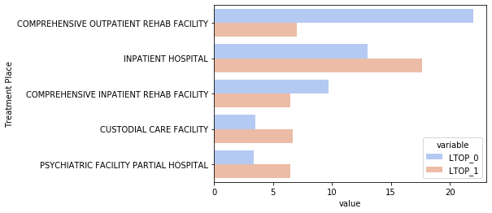

```python
plotcountdiff('event_attr2',FullyPaid,'Treatment Place')
```

## 4. Inbound Calls

```python
Call = EDA_data[(EDA_data['event_descr']=='Inbound Call by Mbr')|
                (EDA_data['event_descr']=='Inbound Call by Prov')|
                (EDA_data['event_descr']=='Inbound Call by Other')&
                (EDA_data['Days']<=0)]
```

```python
getcountdiff('event_attr2',Call,'Call Inquiry')
```

|  | Call Inquiry | LTOP_0 | LTOP_1 | diff |
| --- | --- | --- | --- | --- |
| 846 | OVER 4 DAY AGED | 3.870347 | 5.236211 | 1.365863 |
| 34 | ACTIVITY SUBMISSION | 1.000000 | 2.333333 | 1.333333 |
| 964 | PREMIUM QUESTION | 1.000000 | 2.000000 | 1.000000 |
| 1053 | REFERRAL LETTER INQUIRY | 2.000000 | 1.000000 | 1.000000 |
| 416 | ESRD | 1.000000 | 2.000000 | 1.000000 |

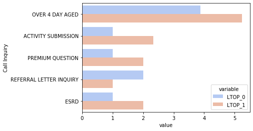

```python
plotcountdiff('event_attr2',Call,'Call Inquiry')
```

```python
getcountdiff('event_attr3',Call,'Diposition')
```

|  | Diposition | LTOP_0 | LTOP_1 | diff |
| --- | --- | --- | --- | --- |
| 265 | ERROR/CALL CENTER | 9.000000 | 1.000000 | 8.000000 |
| 562 | PAYMENT PLAN ADJUSTED | 8.000000 | 1.000000 | 7.000000 |
| 64 | ARRANGED DELIVERY | 7.202312 | 5.875776 | 1.326536 |
| 563 | PAYMENT PLAN SETUP | 2.000000 | 1.000000 | 1.000000 |
| 381 | INSULIN PUMP DEPENDENT | 1.000000 | 2.000000 | 1.000000 |

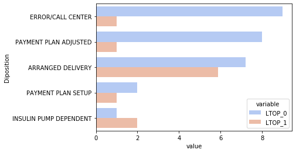

```python
plotcountdiff('event_attr3',Call,'Diposition')
```

# Feature Engineering

[figure not shown]

## 1. Opioid data

```python
# filter out the data only related to RX Claim - Paid
rxClaimPaid = fullData[fullData.event_descr=='RX Claim - Paid'].copy()
```

```python
rxClaimPaid.shape
```

```
(1899090, 20)
```

```python
opioid = rxClaimPaid[rxClaimPaid.PAY_DAY_SUPPLY_CNT >= 0].copy()
```

```python
opioid.shape
```

```
(138549, 20)
```

```python
len(opioid.id.unique())
```

```
19882
```

### 1.1. Get dummies

- define a function to get categorical variables

```python
def getDummies(col, data):
    """
    Get dummy variables for specified column
    """
    df = data[['id', col]].copy()
    df = pd.get_dummies(df.set_index('id'), drop_first=True).groupby(['id']).max().reset_index()
    return df
```

- define a function to get count of events of each patient

```python
def getCount(col, data):
    """
    Get count of events for each id
    """
    df = data.groupby(['id', col])['event_descr'].count().reset_index()
    df = df.pivot(index='id', columns=col, values='event_descr').reset_index().fillna(0)
    return df
```

```python
opioidDrugClass = getCount('event_attr1', opioid) # 1
opioidBrandName = getCount('event_attr5', opioid) # 2
opioidSpecialty = getCount('Specialty', opioid) # 3
```

```python
print(opioidDrugClass.shape)
opioidDrugClass.head(3)
```

```
(19882, 7)
```

| event_attr1 | id | ANTIPERISTALTIC AGENTS | ANTISPASMODICS | OPIOID AGONISTS | OPIOID ANTAGONISTS | OPIOID COMBINATIONS | OPIOID PARTIAL AGONISTS |
| --- | --- | --- | --- | --- | --- | --- | --- |
| 0 | ID10006701904 | 0.0 | 0.0 | 4.0 | 0.0 | 0.0 | 0.0 |
| 1 | ID10010854159 | 0.0 | 0.0 | 1.0 | 0.0 | 0.0 | 0.0 |
| 2 | ID10013863216 | 0.0 | 0.0 | 1.0 | 0.0 | 0.0 | 0.0 |

```python
print(opioidBrandName.shape)
opioidBrandName.head(3)
```

```
(19882, 76)
```

| event_attr5 | id | ACETAMINOPHEN/CAFFEINE/DI | ACETAMINOPHEN/CODEINE | ACETAMINOPHEN/CODEINE #3 | ACETAMINOPHEN/CODEINE #4 | ACETAMINOPHEN/CODEINE PHO | ASCOMP/CODEINE | AVINZA | BELBUCA | BELLADONNA ALKALOIDS & OP | ... | TREZIX | ULTRAM | VICODIN | VICODIN ES | VICODIN HP | VICOPROFEN | XARTEMIS XR | XTAMPZA ER | ZOHYDRO ER | ZUBSOLV |
| --- | --- | --- | --- | --- | --- | --- | --- | --- | --- | --- | --- | --- | --- | --- | --- | --- | --- | --- | --- | --- | --- |
| 0 | ID10006701904 | 0.0 | 0.0 | 0.0 | 0.0 | 0.0 | 0.0 | 0.0 | 0.0 | 0.0 | ... | 0.0 | 0.0 | 0.0 | 0.0 | 0.0 | 0.0 | 0.0 | 0.0 | 0.0 | 0.0 |
| 1 | ID10010854159 | 0.0 | 0.0 | 0.0 | 0.0 | 0.0 | 0.0 | 0.0 | 0.0 | 0.0 | ... | 0.0 | 0.0 | 0.0 | 0.0 | 0.0 | 0.0 | 0.0 | 0.0 | 0.0 | 0.0 |
| 2 | ID10013863216 | 0.0 | 0.0 | 0.0 | 0.0 | 0.0 | 0.0 | 0.0 | 0.0 | 0.0 | ... | 0.0 | 0.0 | 0.0 | 0.0 | 0.0 | 0.0 | 0.0 | 0.0 | 0.0 | 0.0 |

3 rows × 76 columns

```python
print(opioidSpecialty.shape)
opioidSpecialty.head(3)
```

```
(19839, 178)
```

| Specialty | id | Acupuncturist | Allergy & Immunology | Anesthesiology | Anesthesiology Pain Medicine | Chiropractor | Clinic/Center Federally Qualif Hlth Ctr | Clinic/Center Medical Specialty | Clinic/Center Physical Therapy | Clinic/Center Primary Care | ... | Surgery Plastic & Reconstructive Surgery | Surgery Surgical Critical Care | Surgery Surgical Oncology | Surgery Trauma Surgery | Surgery Vascular Surgery | Surgery of the Hand | TRANSPLANT HEPATOLOGY | Technician, Pathology Phlebotomy | Thoracic Surgery Cardiothoracic Vascular | Urology |
| --- | --- | --- | --- | --- | --- | --- | --- | --- | --- | --- | --- | --- | --- | --- | --- | --- | --- | --- | --- | --- | --- |
| 0 | ID10006701904 | 0.0 | 0.0 | 0.0 | 0.0 | 0.0 | 0.0 | 0.0 | 0.0 | 0.0 | ... | 0.0 | 0.0 | 0.0 | 0.0 | 0.0 | 0.0 | 0.0 | 0.0 | 0.0 | 0.0 |
| 1 | ID10010854159 | 0.0 | 0.0 | 0.0 | 0.0 | 0.0 | 0.0 | 0.0 | 0.0 | 0.0 | ... | 0.0 | 0.0 | 0.0 | 0.0 | 0.0 | 0.0 | 0.0 | 0.0 | 0.0 | 0.0 |
| 2 | ID10013863216 | 0.0 | 0.0 | 0.0 | 0.0 | 0.0 | 0.0 | 0.0 | 0.0 | 0.0 | ... | 0.0 | 0.0 | 0.0 | 0.0 | 0.0 | 0.0 | 0.0 | 0.0 | 0.0 | 0.0 |

3 rows × 178 columns

### 1.4. opioidCount (Count of opioid prescriptions)

```python
opioidCount = opioid.groupby('id')['event_descr'].count().reset_index() # 4
opioidCount.columns = ['id', 'opioidCount']
print(opioidCount.shape)
opioidCount.head(3)
```

```
(19882, 2)
```

|  | id | opioidCount |
| --- | --- | --- |
| 0 | ID10006701904 | 4 |
| 1 | ID10010854159 | 1 |
| 2 | ID10013863216 | 1 |

### 1.5. opioidDaysSupplied (Sum of opioid days supplied)

```python
opioidDaysSupplied = opioid.groupby('id')['PAY_DAY_SUPPLY_CNT'].sum().reset_index() # 5
opioidDaysSupplied.columns = ['id', 'opioidDaysSupplied']
print(opioidDaysSupplied.shape)
opioidDaysSupplied.head(3)
```

```
(19882, 2)
```

|  | id | opioidDaysSupplied |
| --- | --- | --- |
| 0 | ID10006701904 | 240.0 |
| 1 | ID10010854159 | 5.0 |
| 2 | ID10013863216 | 90.0 |

### 1.6. opioidDay0Specialty (dummies of Specialty on Day 0)

```python
opioidDay0Specialty = getDummies('Specialty', opioid[opioid.Days==0]) # 6
print(opioidDay0Specialty.shape)
opioidDay0Specialty.head(3)
```

```
(19693, 132)
```

|  | id | Specialty_Allergy & Immunology | Specialty_Anesthesiology | Specialty_Anesthesiology Pain Medicine | Specialty_Chiropractor | Specialty_Clinic/Center Primary Care | Specialty_Clinical Nurse Specialist Gerontology | Specialty_Colon & Rectal Surgery | Specialty_Counselor Mental Health | Specialty_Dentist | ... | Specialty_STUDENT IN ORGANIZED HEALTHCARE EDU/TRAI | Specialty_Specialist | Specialty_Surgery | Specialty_Surgery Plastic & Reconstructive Surgery | Specialty_Surgery Surgical Critical Care | Specialty_Surgery Vascular Surgery | Specialty_Surgery of the Hand | Specialty_TRANSPLANT HEPATOLOGY | Specialty_Thoracic Surgery Cardiothoracic Vascular | Specialty_Urology |
| --- | --- | --- | --- | --- | --- | --- | --- | --- | --- | --- | --- | --- | --- | --- | --- | --- | --- | --- | --- | --- | --- |
| 0 | ID10006701904 | 0 | 0 | 0 | 0 | 0 | 0 | 0 | 0 | 0 | ... | 0 | 0 | 0 | 0 | 0 | 0 | 0 | 0 | 0 | 0 |
| 1 | ID10010854159 | 0 | 0 | 0 | 0 | 0 | 0 | 0 | 0 | 0 | ... | 0 | 0 | 0 | 0 | 0 | 0 | 0 | 0 | 0 | 0 |
| 2 | ID10013863216 | 0 | 0 | 0 | 0 | 0 | 0 | 0 | 0 | 0 | ... | 0 | 0 | 0 | 0 | 0 | 0 | 0 | 0 | 0 | 0 |

3 rows × 132 columns

### 1.7. opioidDay0Supplies (opioid supplies on day 0)

```python
opioidDay0Supplies = opioid[opioid.Days==0][['id','PAY_DAY_SUPPLY_CNT']].groupby('id').max().reset_index() #7
opioidDay0Supplies.columns = ['id', 'opioidDay0Supplies']
print(opioidDay0Supplies.shape)
opioidDay0Supplies.head(3)
```

```
(19693, 2)
```

|  | id | opioidDay0Supplies |
| --- | --- | --- |
| 0 | ID10006701904 | 60.0 |
| 1 | ID10010854159 | 5.0 |
| 2 | ID10013863216 | 90.0 |

## 2. Fully Paid Claim

```python
fullData.event_descr.value_counts()
```

```
RX Claim - Paid                     1899090
Fully Paid Claim                    1170330
RX Claim - Rejected                  515133
Inbound Call by Mbr                  248800
RX Claim - New Drug                  192671
New provider                         133964
Inbound Call by Prov                  91264
Inbound Call by Other                 24250
Surgery                               20992
RX Claim - First Time Mail Order       8020
New diagnosis - CPD                    3534
New diagnosis - Hypertension           3291
New diagnosis - Top 5                  3254
New diagnosis - CAD                    2210
New diagnosis - Diabetes               2124
New diagnosis - CHF                    1695
Name: event_descr, dtype: int64
```

```python
fullyPaidClaim = fullData[fullData.event_descr=='Fully Paid Claim'].copy()
```

```python
fullyPaidClaim.shape
```

```
(1170330, 20)
```

### 2.1. Sum of Amount

- This function is used for calculating the total amount of money each patient spent

```python
def getAmount(event):
    """
    Get Count, ChargeAmount, NetPaidAmount and ResponsibleAmount
        for specified event
    """
    # get fully paid claim data
    data = fullData[fullData.event_descr==event].copy()

    # Convert amount to float
    data['event_attr3'] = data['event_attr3'].apply(float)
    data['event_attr4'] = data['event_attr4'].apply(float)
    data['event_attr5'] = data['event_attr5'].apply(float)

    # Group by sum of charged amount
    groupbyData = data.groupby('id').agg({'event_attr3': ['count', 'sum'],
                                          'event_attr4': 'sum',
                                          'event_attr5': 'sum'})

    groupbyData.columns = [
        'Count', 'ChargeAmount', 'NetPaidAmount', 'ResponsibleAmount']
    groupbyData = groupbyData.reset_index()
    return groupbyData
```

```python
claimAmount = getAmount('Fully Paid Claim') #8
print(claimAmount.shape)
claimAmount.head(3)
```

```
(19899, 5)
```

|  | id | Count | ChargeAmount | NetPaidAmount | ResponsibleAmount |
| --- | --- | --- | --- | --- | --- |
| 0 | ID10006701904 | 81 | 57383.01 | 16921.91 | 1457.72 |
| 1 | ID10010854159 | 43 | 23227.94 | 4274.76 | 1778.33 |
| 2 | ID10013863216 | 20 | 18580.46 | 2893.69 | 602.36 |

### 2.2. Place of Treatment

```python
fullyPaidClaim = fullData[fullData.event_descr=='Fully Paid Claim'].copy()
```

```python
fullyPaidClaimTrainLabel = trainDataLabel[trainDataLabel.event_descr=='Fully Paid Claim'].copy()
```

- This functions is created to show the difference between LTOT and non-LTOT of a particular attribute by calculating the average value of each patient

```python
def getDifference(col, data, n):
    df0 = data.groupby(['id', col, 'LTOP'])['event_descr'].count().reset_index().fillna(0)
    df1 = df0.groupby([col, 'LTOP'])['event_descr'].mean().reset_index()
    df1 = df1.pivot(index=col, columns='LTOP', values='event_descr').reset_index()
    df1.columns = [col, 'LTOP_0', 'LTOP_1']

    df1['diff'] = abs(df1.LTOP_0 - df1.LTOP_1)
    df1 = df1.sort_values('diff', ascending=False)

    differenceList = list(df1[col].head(n))

    return df1, differenceList
```

- This function is used for selecting the values that appear most frequently in a particular attribute

```python
def getPopular(col, data, n):
    df = data.groupby([col])['id'].nunique().reset_index().sort_values('id', ascending=False)
    popularList = list(df[col].head(n))

    return df, popularList
```

- This function is used for creating a list of those most important values we found in the former step

```python
def getImportant(col, data, n1, n2):
    df1, differenceList = getDifference(col, data, n1)
    df2, popularList = getPopular(col, data, n2)

    importantList = []
    for event in differenceList:
        if event in popularList:
            importantList.append(event)

    return importantList
```

- This function is used for getting the count of events of each patient

```python
def getImportantCount(col, importantList, data):
    return getCount(col, data[data[col].apply(lambda event: event in importantList)])
```

```python
importantList = getImportant('event_attr2', fullyPaidClaimTrainLabel, 30, 30) #9
treatmentPlace = getImportantCount('event_attr2', importantList, fullyPaidClaim)

print(treatmentPlace.shape)
treatmentPlace.head(3)
```

```
(19898, 29)
```

| event_attr2 | id | AMBULANCE - LAND | AMBULATORY SURGICAL CENTER | COMMUNITY MENTAL HEALTH CENTER | COMPREHENSIVE INPATIENT REHAB FACILITY | CUSTODIAL CARE FACILITY | EMERGENCY ROOM - HOSPITAL | END STAGE RENAL DISEASE TX FACILITY | FEDERALLY QUALIFIED HEALTH CENTER | HOME | ... | ON CAMPUS-HOSPITAL OUTPATIENT | OTHER/UNKNOWN POT-CD | PHARMACY | PSYCHIATRIC FACILITY PARTIAL HOSPITAL | RURAL HEALTH CLINIC | SKILLED NURSING FACILITY | STATE OR LOCAL PUBLIC HEALTH CLINIC | TEMPORARY LODGING | URGENT CARE FACILITY | WALK-IN RETAIL HEALTH CLINIC |
| --- | --- | --- | --- | --- | --- | --- | --- | --- | --- | --- | --- | --- | --- | --- | --- | --- | --- | --- | --- | --- | --- |
| 0 | ID10006701904 | 1.0 | 0.0 | 0.0 | 0.0 | 0.0 | 8.0 | 0.0 | 0.0 | 7.0 | ... | 9.0 | 0.0 | 0.0 | 0.0 | 0.0 | 1.0 | 0.0 | 0.0 | 0.0 | 0.0 |
| 1 | ID10010854159 | 0.0 | 3.0 | 0.0 | 0.0 | 0.0 | 0.0 | 0.0 | 0.0 | 0.0 | ... | 10.0 | 0.0 | 0.0 | 0.0 | 0.0 | 0.0 | 0.0 | 0.0 | 0.0 | 0.0 |
| 2 | ID10013863216 | 0.0 | 0.0 | 0.0 | 0.0 | 0.0 | 0.0 | 0.0 | 0.0 | 0.0 | ... | 9.0 | 0.0 | 0.0 | 0.0 | 0.0 | 0.0 | 0.0 | 0.0 | 0.0 | 0.0 |

3 rows × 29 columns

### 2.3. Diagnosis

```python
# getDifference('event_attr1', fullyPaidClaimTrain, 30)[0]
# getPopular('event_attr1', fullyPaidClaimTrain, 30)[0]
# getImportant('event_attr1', fullyPaidClaimTrain, 1000, 1000)
```

```python
importantList = getDifference('event_attr1', fullyPaidClaimTrainLabel, 100)[1]
diagnosisClaim = getImportantCount('event_attr1', importantList, fullyPaidClaim) #10

print(diagnosisClaim.shape)
diagnosisClaim.head(3)
```

```
(791, 101)
```

| event_attr1 | id | ACUTE MYOCARDIAL INFARCTION OF ANTEROLATERAL WALL, EPISODE OF CARE UNSPECIFIED | ADRENOGENITAL DISORDER, UNSPECIFIED | ALCOHOLIC LIVER DISEASE, UNSPECIFIED | ALLERGIC PURPURA | ANTINEOPLASTIC CHEMOTHERAPY INDUCED PANCYTOPENIA | ATAXIA FOLLOWING UNSPECIFIED CEREBROVASCULAR DISEASE | CAUSALGIA OF UNSPECIFIED LOWER LIMB | CHRONIC ANGLE-CLOSURE GLAUCOMA, BILATERAL, SEVERE STAGE | CHRONIC INFLAMMATORY DEMYELINATING POLYNEURITIS | ... | UNSPECIFIED FRACTURE OF LEFT LOWER LEG, INITIAL ENCOUNTER FOR CLOSED FRACTURE | UNSPECIFIED FRACTURE OF SHAFT OF RIGHT ULNA, INITIAL ENCOUNTER FOR CLOSED FRACTURE | UNSPECIFIED INJURY OF BLADDER, INITIAL ENCOUNTER | UNSPECIFIED INTRACAPSULAR FRACTURE OF UNSPECIFIED FEMUR, INITIAL ENCOUNTER FOR CLOSED FRACTURE | UNSPECIFIED MYCOSIS | UNSPECIFIED OPEN WOUND OF RIGHT GREAT TOE WITHOUT DAMAGE TO NAIL, INITIAL ENCOUNTER | UNSPECIFIED OPEN WOUND OF UNSPECIFIED BUTTOCK, SUBSEQUENT ENCOUNTER | UNSPECIFIED PARALYSIS | VESICOINTESTINAL FISTULA | WEGENER'S GRANULOMATOSIS WITHOUT RENAL INVOLVEMENT |
| --- | --- | --- | --- | --- | --- | --- | --- | --- | --- | --- | --- | --- | --- | --- | --- | --- | --- | --- | --- | --- | --- |
| 0 | ID1002482139 | 0.0 | 0.0 | 0.0 | 0.0 | 0.0 | 0.0 | 0.0 | 0.0 | 0.0 | ... | 0.0 | 0.0 | 0.0 | 0.0 | 0.0 | 0.0 | 0.0 | 0.0 | 0.0 | 0.0 |
| 1 | ID10161175490 | 0.0 | 0.0 | 0.0 | 0.0 | 0.0 | 0.0 | 0.0 | 0.0 | 0.0 | ... | 0.0 | 0.0 | 0.0 | 0.0 | 0.0 | 0.0 | 0.0 | 0.0 | 0.0 | 0.0 |
| 2 | ID10201747254 | 0.0 | 0.0 | 11.0 | 0.0 | 0.0 | 0.0 | 0.0 | 0.0 | 0.0 | ... | 0.0 | 0.0 | 0.0 | 0.0 | 0.0 | 0.0 | 0.0 | 0.0 | 0.0 | 0.0 |

3 rows × 101 columns

## 3. RX Claim

### 3.1. Drug Class

```python
rxClaimPaidLabel = rxClaimPaid.merge(label, on='id')
```

```python
drugClass = getImportantCount('event_attr1', getImportant('event_attr1', rxClaimPaidLabel, 200, 200), rxClaimPaid) #11
print(drugClass.shape)
drugClass.head(3)
```

```
(19981, 96)
```

| event_attr1 | id | 5-HT3 RECEPTOR ANTAGONISTS | ACNE PRODUCTS | AMINOGLYCOSIDES | AMPHETAMINES | ANALGESIC COMBINATIONS | ANDROGENS | ANGIOTENSIN II RECEPTOR ANTAGONISTS | ANOREXIANTS NON-AMPHETAMINE | ANTACIDS - BICARBONATE | ... | STEROID INHALANTS | STIMULANTS - MISC. | SURFACTANT LAXATIVES | THROMBIN INHIBITORS | URINARY ANTISPASMODIC - ANTIMUSCARINICS (ANTICHOLINERGIC) | URINARY ANTISPASMODICS - BETA-3 ADRENERGIC AGONISTS | VAGINAL ANTI-INFECTIVES | VALPROIC ACID | WATER SOLUBLE VITAMINS | XANTHINES |
| --- | --- | --- | --- | --- | --- | --- | --- | --- | --- | --- | --- | --- | --- | --- | --- | --- | --- | --- | --- | --- | --- |
| 0 | ID10006701904 | 0.0 | 0.0 | 0.0 | 0.0 | 0.0 | 0.0 | 0.0 | 0.0 | 0.0 | ... | 0.0 | 0.0 | 0.0 | 0.0 | 0.0 | 0.0 | 0.0 | 0.0 | 0.0 | 0.0 |
| 1 | ID10010854159 | 0.0 | 0.0 | 0.0 | 0.0 | 0.0 | 0.0 | 0.0 | 0.0 | 0.0 | ... | 0.0 | 0.0 | 0.0 | 0.0 | 0.0 | 0.0 | 0.0 | 0.0 | 0.0 | 0.0 |
| 2 | ID10013863216 | 0.0 | 0.0 | 0.0 | 0.0 | 0.0 | 0.0 | 0.0 | 0.0 | 0.0 | ... | 0.0 | 0.0 | 0.0 | 0.0 | 0.0 | 0.0 | 0.0 | 0.0 | 0.0 | 0.0 |

3 rows × 96 columns

### 3.2. Drug Group

```python
drugGroup = getCount('event_attr6', rxClaimPaid) #12
print(drugGroup.shape)
drugGroup.head()
```

```
(19982, 29)
```

| event_attr6 | id | CANCER | CARDIO | DERM | DIABETES | GASTRO | GENDER-FEMALE | GENDER-MALE | INF-ANTIBIOTICS | LAXATIVE/BLADDER | ... | OTH-THYROID | OTHER | OTHER ANTI INFECTIVES | PAIN | PSYCH | PSYCH-ANX | PSYCH-DEP | RESPIRATORY | SENSE ORGANS EARS/EYES/MOUTH | SUPPLIES/SUPPLEMENTS/TESTS |
| --- | --- | --- | --- | --- | --- | --- | --- | --- | --- | --- | --- | --- | --- | --- | --- | --- | --- | --- | --- | --- | --- |
| 0 | ID10006701904 | 0.0 | 22.0 | 3.0 | 0.0 | 10.0 | 0.0 | 0.0 | 3.0 | 0.0 | ... | 7.0 | 18.0 | 2.0 | 7.0 | 0.0 | 0.0 | 0.0 | 0.0 | 0.0 | 0.0 |
| 1 | ID10010854159 | 0.0 | 40.0 | 0.0 | 9.0 | 3.0 | 0.0 | 0.0 | 6.0 | 0.0 | ... | 0.0 | 1.0 | 1.0 | 8.0 | 0.0 | 0.0 | 0.0 | 1.0 | 3.0 | 0.0 |
| 2 | ID10013863216 | 0.0 | 2.0 | 1.0 | 0.0 | 0.0 | 0.0 | 0.0 | 1.0 | 0.0 | ... | 0.0 | 1.0 | 0.0 | 1.0 | 0.0 | 0.0 | 0.0 | 0.0 | 0.0 | 0.0 |
| 3 | ID10020514442 | 0.0 | 46.0 | 0.0 | 0.0 | 0.0 | 0.0 | 0.0 | 0.0 | 0.0 | ... | 0.0 | 0.0 | 0.0 | 4.0 | 0.0 | 0.0 | 0.0 | 0.0 | 0.0 | 26.0 |
| 4 | ID10024447278 | 0.0 | 16.0 | 0.0 | 5.0 | 0.0 | 0.0 | 0.0 | 2.0 | 0.0 | ... | 0.0 | 1.0 | 0.0 | 5.0 | 0.0 | 0.0 | 0.0 | 0.0 | 0.0 | 14.0 |

5 rows × 29 columns

### 3.2. RxCost

```python
rxClaimPaid.shape
```

```
(1899090, 20)
```

- This function is created to get the total number and costs of RX Claim

```python
def getRxCost():
    """
    Get total RxCost and NetPaidAmount for Rx Claim Paid
    """
    # get fully paid claim data
    data = rxClaimPaid.copy()

    # Convert amount to float
    data['event_attr3'] = data['event_attr3'].apply(float)
    data['event_attr4'] = data['event_attr4'].apply(float)

    # Group by sum of charged amount
    groupbyData = data.groupby('id').agg({'event_attr3': ['count', 'sum'],
                                          'event_attr4': 'sum'})

    groupbyData.columns = [
        'Count', 'RxCost', 'NetPaidAmount']
    groupbyData = groupbyData.reset_index()
    return groupbyData
```

```python
rxCost = getRxCost() #13
print(rxCost.shape)
rxCost.head(3)
```

```
(19982, 4)
```

|  | id | Count | RxCost | NetPaidAmount |
| --- | --- | --- | --- | --- |
| 0 | ID10006701904 | 80 | 11765.44 | 11590.77 |
| 1 | ID10010854159 | 76 | 1335.77 | 1170.11 |
| 2 | ID10013863216 | 9 | 125.12 | 65.94 |

## 4. Inbound Call

```python
inboundCall = fullData[fullData['event_descr'].apply(
    lambda event: event in ['Inbound Call by Mbr',
                            'Inbound Call by Prov',
                            'Inbound Call by Other'])].copy()
```

```python
inboundCallLabel = inboundCall.merge(label, on='id')
```

### 4.1. Call category

```python
callCategory = getImportantCount('event_attr1',
                                   getImportant('event_attr1', inboundCallLabel, 200, 200), inboundCall)  # 14
print(callCategory.shape)
callCategory.head(3)
```

```
(18310, 185)
```

| event_attr1 | id | ACCESS TO CARE(NOT IN SYSTEM) | ANNUAL NOTIFICATION OF CHANGE (ANOC) | AUTH-REFERRAL | AUTH-REFERRAL (MCRU) | AUTH-REFERRAL (RSO) | AUTH-REFERRAL UPDATED | AUTH/REFERRAL | AUTHORIZATIONS | AUTHORIZATIONS RX | ... | VENDOR | VERIFICATION | VOB | VOB RX | WEB | WEB-MOBILE | WEB/MOBILE | WEBSITE (CT & TM) | WELL DINE | WELLNESS |
| --- | --- | --- | --- | --- | --- | --- | --- | --- | --- | --- | --- | --- | --- | --- | --- | --- | --- | --- | --- | --- | --- |
| 0 | ID10006701904 | 0.0 | 0.0 | 0.0 | 0.0 | 0.0 | 0.0 | 0.0 | 1.0 | 0.0 | ... | 0.0 | 0.0 | 11.0 | 0.0 | 0.0 | 0.0 | 0.0 | 0.0 | 0.0 | 0.0 |
| 1 | ID10010854159 | 0.0 | 0.0 | 0.0 | 0.0 | 0.0 | 0.0 | 0.0 | 1.0 | 1.0 | ... | 0.0 | 0.0 | 4.0 | 0.0 | 0.0 | 0.0 | 0.0 | 0.0 | 0.0 | 0.0 |
| 2 | ID10013863216 | 0.0 | 0.0 | 0.0 | 0.0 | 0.0 | 0.0 | 0.0 | 0.0 | 0.0 | ... | 0.0 | 0.0 | 3.0 | 0.0 | 0.0 | 0.0 | 0.0 | 0.0 | 0.0 | 0.0 |

3 rows × 185 columns

### 4.2. Inquiry

```python
# getDifference('event_attr2', inboundCallLabel, 30)[0]
# getPopular('event_attr1', rxClaimPaidLabel, 30)[0]
# getImportant('event_attr2', inboundCallLabel, 100, 100)
# callCategory = getImportantDummies('event_attr1', getImportant('event_attr1', inboundCallLabel, 200, 200), inboundCall) # 14

callInquiry = getImportantCount('event_attr2',
                                   getImportant('event_attr2', inboundCallLabel, 200, 200), inboundCall)  # 15
print(callInquiry.shape)
callInquiry.head(3)
```

```
(16624, 51)
```

| event_attr2 | id | AMBULATORY PYMT CLASS | AUTH/REFERRAL NOT OBTAINED | AUTHORIZATION | BALANCE INQUIRY | BENEFITS/NEW RX | BILLING ISSUES | CHECK INFO/RECOUPMENT | CLAIM DENIED | CLAIM PENDED | ... | SMARTSUMMARY | SNF/HOME HEALTH | TECH CONSULT | TEST | TRANSFERRED | TRANSPORTATION | VACATION OVERRIDE | VERIFICATION | WEB ACCESS | WEB SITE |
| --- | --- | --- | --- | --- | --- | --- | --- | --- | --- | --- | --- | --- | --- | --- | --- | --- | --- | --- | --- | --- | --- |
| 0 | ID10006701904 | 0.0 | 0.0 | 0.0 | 4.0 | 2.0 | 0.0 | 1.0 | 3.0 | 2.0 | ... | 0.0 | 2.0 | 13.0 | 0.0 | 2.0 | 0.0 | 0.0 | 1.0 | 0.0 | 0.0 |
| 1 | ID10010854159 | 0.0 | 0.0 | 0.0 | 1.0 | 3.0 | 1.0 | 0.0 | 1.0 | 1.0 | ... | 0.0 | 0.0 | 0.0 | 0.0 | 1.0 | 0.0 | 0.0 | 2.0 | 0.0 | 0.0 |
| 2 | ID10024447278 | 0.0 | 0.0 | 0.0 | 0.0 | 1.0 | 1.0 | 0.0 | 0.0 | 0.0 | ... | 0.0 | 0.0 | 0.0 | 0.0 | 2.0 | 0.0 | 0.0 | 1.0 | 0.0 | 0.0 |

3 rows × 51 columns

### 4.3. Disposition

```python
callDisposition = getImportantCount('event_attr3',
                                      getImportant('event_attr3', inboundCallLabel, 200, 200), inboundCall)  # 16
print(callDisposition.shape)
callDisposition.head(3)
```

```
(17939, 86)
```

| event_attr3 | id | ACH UPDATED/CHANGED | ADDRESSED/ADMINISTRATION | ADDRESSED/DRUG-DRUG INTERACTIONS | ADDRESSED/OTHER | ADVISED NO POA ON FILE/CONSENT FORM ON FILE | ARRANGED DELIVERY | AUTHORIZATION ENTERED | AUTHORIZED | BALANCE INQUIRY | ... | TRANSFERRED TO HEALTHHELP | TRANSFERRED TO MEDICAL CCR | TRANSFERRED TO ORTHONET | TRANSFERRED TO OTC | TRANSFERRED TO PHARMACIST | TRANSFERRED TO RIGHTSOURCE | TRANSFERRED TO RSSP | UNABLE TO UPDATE INFORMATION | WEB EMULATION | WEB NAVIGATION EDUCATION PROVIDED |
| --- | --- | --- | --- | --- | --- | --- | --- | --- | --- | --- | --- | --- | --- | --- | --- | --- | --- | --- | --- | --- | --- |
| 0 | ID10006701904 | 0.0 | 0.0 | 0.0 | 1.0 | 0.0 | 0.0 | 0.0 | 4.0 | 0.0 | ... | 0.0 | 3.0 | 0.0 | 0.0 | 2.0 | 0.0 | 0.0 | 0.0 | 0.0 | 0.0 |
| 1 | ID10010854159 | 0.0 | 1.0 | 0.0 | 0.0 | 0.0 | 0.0 | 1.0 | 0.0 | 1.0 | ... | 0.0 | 2.0 | 0.0 | 0.0 | 1.0 | 0.0 | 0.0 | 0.0 | 0.0 | 0.0 |
| 2 | ID10013863216 | 0.0 | 0.0 | 0.0 | 0.0 | 0.0 | 0.0 | 0.0 | 0.0 | 0.0 | ... | 0.0 | 0.0 | 0.0 | 0.0 | 0.0 | 0.0 | 0.0 | 0.0 | 0.0 | 0.0 |

3 rows × 86 columns

### 4.4. Location

```python
inboundCall['state'] = inboundCall['event_attr5'].fillna(
    'Na, Na').apply(lambda location: location.split(', ')[1])

callState = getDummies('state', inboundCall) # 17
print(callState.shape)
callState.head(3)
```

```
(18316, 16)
```

|  | id | state_AL | state_AZ | state_FL | state_ID | state_KS | state_KY | state_NC | state_Na | state_OH | state_PR | state_TN | state_TX | state_UT | state_WA | state_WI |
| --- | --- | --- | --- | --- | --- | --- | --- | --- | --- | --- | --- | --- | --- | --- | --- | --- |
| 0 | ID10006701904 | 0 | 1 | 0 | 0 | 0 | 1 | 1 | 1 | 1 | 0 | 0 | 1 | 1 | 0 | 1 |
| 1 | ID10010854159 | 0 | 1 | 0 | 0 | 0 | 1 | 0 | 1 | 1 | 0 | 0 | 1 | 0 | 0 | 0 |
| 2 | ID10013863216 | 0 | 0 | 0 | 0 | 0 | 1 | 0 | 0 | 0 | 0 | 0 | 0 | 0 | 0 | 0 |

## 5. Sum of Charge

```python
fullData.event_descr.value_counts()
```

[output not shown]

```python
surgeryAmount = getAmount('Surgery') # 18
print(surgeryAmount.shape)
surgeryAmount.head(3)
```

```
(9080, 5)
```

|  | id | Count | ChargeAmount | NetPaidAmount | ResponsibleAmount |
| --- | --- | --- | --- | --- | --- |
| 0 | ID10006701904 | 1 | 2138.90 | 197.10 | 275.0 |
| 1 | ID10010854159 | 1 | 2314.00 | 619.08 | 250.0 |
| 2 | ID10013863216 | 1 | 12337.42 | 1396.98 | 275.0 |

```python
newCPDAmount = getAmount('New diagnosis - CPD') # 19
print(newCPDAmount.shape)
newCPDAmount.head(3)
```

```
(3534, 5)
```

|  | id | Count | ChargeAmount | NetPaidAmount | ResponsibleAmount |
| --- | --- | --- | --- | --- | --- |
| 0 | ID1002482139 | 1 | 137.0 | 0.00 | 0.0 |
| 1 | ID10052944491 | 1 | 115.0 | 99.00 | 15.0 |
| 2 | ID1007116120 | 1 | 1431.1 | 187.44 | 0.0 |

```python
newHyperAmount = getAmount('New diagnosis - Hypertension') # 20
print(newHyperAmount.shape)
newHyperAmount.head(3)
```

```
(3291, 5)
```

|  | id | Count | ChargeAmount | NetPaidAmount | ResponsibleAmount |
| --- | --- | --- | --- | --- | --- |
| 0 | ID10112532931 | 1 | 640.0 | 59.23 | 0.0 |
| 1 | ID10189080475 | 1 | 1078.0 | 213.53 | 0.0 |
| 2 | ID10230809175 | 1 | 80.0 | 47.03 | 20.0 |

```python
newTop5Amount = getAmount('New diagnosis - Top 5') # 21
print(newTop5Amount.shape)
newTop5Amount.head(3)
```

```
(3254, 5)
```

|  | id | Count | ChargeAmount | NetPaidAmount | ResponsibleAmount |
| --- | --- | --- | --- | --- | --- |
| 0 | ID10112532931 | 1 | 5333.00 | 0.00 | 0.0 |
| 1 | ID10169051312 | 1 | 0.01 | 0.00 | 0.0 |
| 2 | ID10230809175 | 1 | 80.00 | 47.03 | 20.0 |

```python
newCHFAmount = getAmount('New diagnosis - CHF') # 22
print(newCHFAmount.shape)
newCHFAmount.head(3)
```

```
(1695, 5)
```

|  | id | Count | ChargeAmount | NetPaidAmount | ResponsibleAmount |
| --- | --- | --- | --- | --- | --- |
| 0 | ID10006701904 | 1 | 2296.74 | 0.00 | 0.0 |
| 1 | ID10020514442 | 1 | 118.00 | 62.90 | 0.0 |
| 2 | ID10074598346 | 1 | 185.00 | 23.52 | 50.0 |

```python
newDiabAmount = getAmount('New diagnosis - Diabetes') # 23
print(newDiabAmount.shape)
newDiabAmount.head(3)
```

```
(2124, 5)
```

|  | id | Count | ChargeAmount | NetPaidAmount | ResponsibleAmount |
| --- | --- | --- | --- | --- | --- |
| 0 | ID10006701904 | 1 | 6.52 | 0.00 | 0.0 |
| 1 | ID10112532931 | 1 | 2513.00 | 1188.32 | 0.0 |
| 2 | ID10119459922 | 1 | 20.55 | 0.00 | 0.0 |

## 6. Merge

```python
features = [opioidDrugClass, opioidBrandName, opioidSpecialty, opioidCount,
           opioidDaysSupplied, opioidDay0Specialty, opioidDay0Supplies, claimAmount,
           treatmentPlace, diagnosisClaim, drugClass, drugGroup,
           rxCost, callCategory, callInquiry, callDisposition, callState,
           surgeryAmount, newCPDAmount, newHyperAmount, newTop5Amount, newCHFAmount, newDiabAmount]
```

```python
from functools import reduce
mergedDf = reduce(lambda left, right: pd.merge(
    left, right, on=['id'], how='outer'), features)
```

```python
# Impute missing value
mergedDf = mergedDf.fillna(0)
```

```python
mergedDf.shape
```

```
(19982, 1009)
```

```python
# Split train data and test data
trainDf = mergedDf.merge(trainID, on='id')
testDf = mergedDf.merge(testID, on='id')
```

```python
# Add label to train data
trainDf = trainDf.merge(label, how='outer', on='id').fillna(0)
```

```python
# Save data
trainDf.to_csv('trainDf.csv', index=False)
testDf.to_csv('testDf.csv', index=False)
```

# Recursive Feature Elimination

```python
# import useful packages
from sklearn import datasets
from sklearn import metrics
from sklearn.ensemble import ExtraTreesClassifier
from sklearn.model_selection import StratifiedKFold
from sklearn.feature_selection import RFECV, RFE
import warnings
warnings.filterwarnings('ignore')
pd.options.display.max_columns = None
```

```python
X = trainDf.drop(['LTOP','id'], axis=1)
target = trainDf['LTOP']
```

```python
from sklearn.ensemble import ExtraTreesClassifier
```

```python
model = ExtraTreesClassifier()
model.fit(X, target)
```

```
ExtraTreesClassifier(bootstrap=False, class_weight=None, criterion='gini',
                     max_depth=None, max_features='auto', max_leaf_nodes=None,
                     min_impurity_decrease=0.0, min_impurity_split=None,
                     min_samples_leaf=1, min_samples_split=2,
                     min_weight_fraction_leaf=0.0, n_estimators=10, n_jobs=None,
                     oob_score=False, random_state=None, verbose=0,
                     warm_start=False)
```

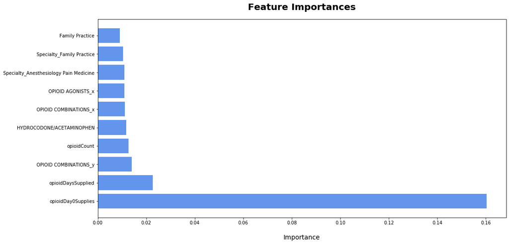

```python
# visualize the important features
dset = pd.DataFrame()
dset['attr'] = X.columns
dset['importance'] = model.feature_importances_
dset = dset.sort_values(by='importance', ascending=False)
dplot = dset.head(10)

plt.figure(figsize=(16, 8))
plt.barh(y=dplot['attr'], width=dplot['importance'], color='cornflowerblue')
plt.title('Feature Importances', fontsize=20, fontweight='bold', pad=20)
plt.xlabel('Importance', fontsize=14, labelpad=20)
plt.show()
```

## Recommendations based on the result

[figure not shown]

### 1. Opioid Data

- The first two features are Opioid Day 0 Supplies, which refers to the opioid drug supplies on day 0 and Opioid Days Supplied, which means the sum of opioid days supplied. They convey the information about how deeply the patients relied on opioid drugs. If patients get a lot more opioid drugs on the first day, they are more likely to order more in the future, while opioid days supplied are a direct indicator of LTOT, which undoubtedly greatly contributes to the predictions.
- Opioid Agonists and Opioid Combinations belong to opioid drug class, which implies that patients who order these two kinds of drugs are more likely to have LTOT. Also, in Opioid Combinations, Hydrocodone/Acetaminophen may be the most important brand.
- As for the specialty on day 0, Specialty_Anesthesiology Pain Medicine and Speciaty_Family Practice stand out. Patients who receive opioids from doctors who specialized in Anesthesiology Pain Medicine and Family Practice have a higher probability of having LTOT.
- Opioid Count is the count of opioid prescriptions. If a patient has more RX claims related to opioids, he/she may get more chances to have LTOT in the future.

# Modeling

[figure not shown]

## 1. Load Data

```python
trainDf = pd.read_csv("/content/trainDf.csv")
testDf = pd.read_csv("/content/testDf.csv")
```

```python
testID = pd.read_csv("/content/testID.csv")
```

```python
print(trainDf.shape)
print(testDf.shape)
```

```
(13997, 1010)
(5998, 1009)
```

## 2. Feature Scaling

- Feature scaling basically helps to normalise the data within a particular range.It also helps in speeding up the calculations in logistic algorithm.

```python
allData = pd.concat([trainDf.drop(['LTOP'], axis=1).set_index('id'), testDf.set_index('id')], axis=0)
```

```python
from sklearn.preprocessing import StandardScaler

scaler = StandardScaler()
allData = pd.DataFrame(scaler.fit_transform(allData), columns=allData.columns)
```

```python
X = allData.iloc[:13997, ]
X_testDf = allData.iloc[13997:, ]

y = trainDf.LTOP
```

```python
print(X.shape)
print(y.shape)
print(X_testDf.shape)
```

```
(13997, 1008)
(13997,)
(5998, 1008)
```

## 3. Model Tuning

```python
from sklearn.model_selection import train_test_split

X_train, X_test, y_train, y_test = train_test_split(
    X, y, test_size=0.2, random_state=2019)
```

```python
from sklearn.metrics import confusion_matrix, classification_report, accuracy_score, roc_curve, auc, roc_auc_score
from sklearn.model_selection import KFold, cross_val_score
```

- This function is created to show the confusion matrix and classification report of the model

```python
def getAccuracy(model, threshold):

    model.fit(X_train, y_train)
    probs = model.predict_proba(X_test)[:, 1]
    y_pred = np.where(probs >= threshold, 1, 0)

    print("Confusion Matrix:\n", confusion_matrix(y_test, y_pred))
    print("\n")
    print("Classification Report:\n",classification_report(y_test, y_pred))
    return accuracy_score(y_test, y_pred)
```

- This function is used for excuting a 10-fold cross validation

```python
n_folds = 10

def cv_ROC_AUC(model):
    """
    Return the average AUC score.
    """
    # Set KFold to shuffle data before the split
    kf = KFold(n_folds, shuffle=True, random_state=42)

    # Get accuracy score
    roc_auc = cross_val_score(model, X, y, scoring="roc_auc", cv=kf)

    return roc_auc.mean()
```

- This fuction is used for getting the ROC score of the model

```python
def get_ROC_AUC(model):
    """
    Return AUC score
    """
    model.fit(X_train, y_train)
    probs = model.predict_proba(X_test)[:,1]
    roc_auc = roc_auc_score(y_test, probs)
    return roc_auc
```

- This function is created to visualize the ROC AUC and find the optimal threshold of the model

```python
def plotROC(model):
    """
    1. Plot ROC AUC
    2. Return the best threshold
    """
    model.fit(X_train, y_train)
    probs = model.predict_proba(X_test)
    preds = probs[:,1]
    fpr, tpr, threshold = roc_curve(y_test, preds)
    roc_auc = auc(fpr, tpr)

    # Plot ROC AUC
    plt.title('Receiver Operating Characteristic')
    plt.plot(fpr, tpr, 'b', label = 'AUC = %0.2f' % roc_auc)
    plt.legend(loc = 'lower right')
    plt.plot([0, 1], [0, 1],'r--')
    plt.xlim([0, 1])
    plt.ylim([0, 1])
    plt.ylabel('True Positive Rate')
    plt.xlabel('False Positive Rate')
    plt.show()

    # Find optimal threshold
    rocDf = pd.DataFrame({'fpr': fpr, 'tpr':tpr, 'threshold':threshold})
    rocDf['tpr - fpr'] = rocDf.tpr - rocDf.fpr
    optimalThreshold = rocDf.threshold[rocDf['tpr - fpr'].idxmax()]

    return optimalThreshold
```

- This function is created to display the results of modeling

```python
def evaluate(model):
    optimalThreshold = plotROC(model)
    print("Optimal Threshold: ", optimalThreshold)
    print("\n")
    print("Accuracy: ", getAccuracy(model, optimalThreshold))
```

### 3.1 Random Forest

```python
from sklearn.ensemble import RandomForestClassifier
```

```python
rfc = RandomForestClassifier(n_estimators=1000)
print("AUC score: ", get_ROC_AUC(rfc))
```

```
AUC score:  0.8643438495519058
```

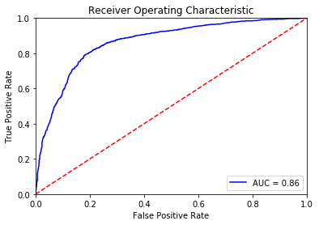

```
Optimal Threshold:  0.539


Confusion Matrix:
 [[1301  293]
 [ 250  956]]


Classification Report:
               precision    recall  f1-score   support

         0.0       0.84      0.82      0.83      1594
         1.0       0.77      0.79      0.78      1206

    accuracy                           0.81      2800
   macro avg       0.80      0.80      0.80      2800
weighted avg       0.81      0.81      0.81      2800

Accuracy:  0.8060714285714285
```

```python
evaluate(rfc)
```

### 3.2 Logistic Regression

```python
from sklearn.linear_model import LogisticRegression
```

```python
logit = LogisticRegression(penalty='l1', C=0.5, max_iter=1000)
print("AUC score: ", get_ROC_AUC(logit))
```

```
AUC score:  0.8342988112553085
```

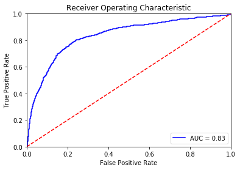

```
Optimal Threshold:  0.39689265894596626


Confusion Matrix:
 [[1232  362]
 [ 257  949]]


Classification Report:
               precision    recall  f1-score   support

         0.0       0.83      0.77      0.80      1594
         1.0       0.72      0.79      0.75      1206

    accuracy                           0.78      2800
   macro avg       0.78      0.78      0.78      2800
weighted avg       0.78      0.78      0.78      2800

Accuracy:  0.7789285714285714
```

```python
evaluate(logit)
```

### 3.3 LightGBM

```python
from lightgbm import LGBMClassifier
```

```
Parameter:  500 	AUC score:  0.8708725298642713
Parameter:  1000 	AUC score:  0.871080607002628
Parameter:  1500 	AUC score:  0.8698815624928474
```

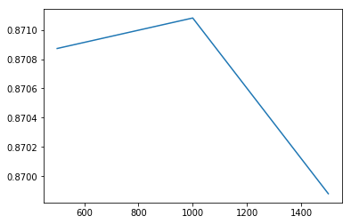

```python
# Model tuning
paraList = [500, 1000, 1500]
roc_auc_list = []

for i in paraList:
    lgb = LGBMClassifier(objective='binary',
                         learning_rate=0.049,
                         n_estimators=i, # 1462
                         num_leaves=8,
                         min_data_in_leaf=4,
                         max_depth=3,
                         max_bin=41,
                         bagging_fraction=0.845,
                         bagging_freq=5,
                         feature_fraction=0.24,
                         feature_fraction_seed=9,
                         bagging_seed=9,
                         min_sum_hessian_in_leaf=11)
    roc_auc = get_ROC_AUC(lgb)
    roc_auc_list.append(roc_auc)
    print("Parameter: ", i, "\tAUC score: ", roc_auc)

plt.plot(np.array(paraList),
         np.array(roc_auc_list))
```

```python
# Best model chosen after tuning
lgb = LGBMClassifier(objective='binary',
                        learning_rate=0.03,
                        n_estimators=1130,
                        num_leaves=8,
                        min_data_in_leaf=1,
                        max_depth=10,
                        max_bin=80,
                        bagging_fraction=0.8,
                        bagging_freq=5,
                        feature_fraction=0.24,
                        feature_fraction_seed=9,
                        bagging_seed=9,
                        min_sum_hessian_in_leaf=12)
cv_ROC_AUC(lgb)
```

```
0.8741430509656014
```

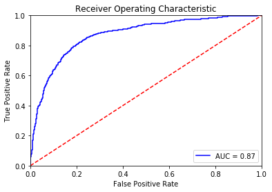

```
Optimal Threshold:  0.37778002376412156


Confusion Matrix:
 [[1206  388]
 [ 176 1030]]


Classification Report:
               precision    recall  f1-score   support

         0.0       0.87      0.76      0.81      1594
         1.0       0.73      0.85      0.79      1206

    accuracy                           0.80      2800
   macro avg       0.80      0.81      0.80      2800
weighted avg       0.81      0.80      0.80      2800

Accuracy:  0.7985714285714286
```

```python
evaluate(lgb)
```

# Predict

### choose LightGBM as the final model

```python
# Use test data to make predictions
lgb.fit(X, y)
predictions = lgb.predict_proba(X_testDf)[:, 1]
```

- Calculate the probability of LTOT for each patient and rank them by descending order

```python
output = pd.DataFrame({'ID': testDf.id,
                       'SCORE': predictions})

testID.columns = ['ID']
output = output.merge(testID, on='ID', how='outer').fillna(0)
output['RANK'] = output.SCORE.rank(method='min', ascending=False)
output = output.sort_values('SCORE', ascending=False)
output.head(10)
```

|  | ID | SCORE | RANK |
| --- | --- | --- | --- |
| 5026 | ID85903555148 | 0.995055 | 1.0 |
| 1365 | ID3065072932 | 0.992463 | 2.0 |
| 4319 | ID74889635841 | 0.989188 | 3.0 |
| 4261 | ID74172758671 | 0.987919 | 4.0 |
| 5063 | ID86509078362 | 0.986938 | 5.0 |
| 1977 | ID40152538353 | 0.986662 | 6.0 |
| 644 | ID19551240941 | 0.986612 | 7.0 |
| 735 | ID21086130021 | 0.986352 | 8.0 |
| 2245 | ID44040914598 | 0.986309 | 9.0 |
| 5192 | ID88456216402 | 0.985301 | 10.0 |

```python
pd.Series(np.where(output.SCORE >= 0.5, 1, 0)).value_counts()
```

```
1    3019
0    2981
dtype: int64
```

```python
y.value_counts()
```

```
0.0    7670
1.0    6327
Name: LTOP, dtype: int64
```

[figure not shown]